# Ford Go Bike Trip Data (Exploratory Analysis)

## Preliminary Wrangling

> Bay Wheels is a regional public bicycle sharing system in California's San Francisco Bay Area. It is operated by Motivate in a partnership with the Metropolitan Transportation Commission and the Bay Area Air Quality Management District. Bay Wheels is the first regional and large-scale bicycle sharing system deployed in California and on the West Coast of the United States. It was established as Bay Area Bike Share in August 2013. As of January 2018, the Bay Wheels system had over 2,600 bicycles in 262 stations across San Francisco, East Bay and San Jose.

> In June 2017 the system was officially re-launched as Ford GoBike in a partnership with Ford Motor Company. After Motivate's acquisition by Lyft, the system was renamed to Bay Wheels in June 2019. The system is expected to expand to 7,000 bicycles around 540 stations in San Francisco, Oakland, Berkeley, Emeryville, and San Jose.

> The dataset used for this exploratory analysis consists of monthly individual trip data during February 2019 in CSV format contain approximately 183,412 rows.

### Introduction

Exploratory data visualization generally occurs during and after the data wrangling process, and is the main method that I will use to understand the patterns and relationships present in FordGoBike trip data. This understanding will help me approach any statistical analyses and will help me build conclusions and findings.

```python
# importing required libraries
import numpy as np
import pandas as pd
import matplotlib.pyplot as plt
import seaborn as sb
import requests
import re
import datetime
import os
import statsmodels.api as sm
import scipy
from functools import reduce
import warnings
from calendar import day_name

warnings.filterwarnings('ignore')
%matplotlib inline
```

### Data Gathering

- **FordGoBike Trip Data**
  - This file (201902-fordgobike-tripdata.csv) is hosted on Udacity's servers and should be downloaded programmatically using the Requests library and the following:

    URL: https://video.udacity-data.com/topher/2020/October/5f91cf38_201902-fordgobike-tripdata/201902-fordgobike-tripdata.csv

```python
# Function definition for dataset download

def request_file(url):
    file_name = os.path.basename(url)
    response = requests.get(url)
    # save content of response in the file
    if not os.path.isfile(file_name):
        with open(file_name,'wb') as f:
            f.write(response.content)
    return file_name
```

```python
# URL downloaded programatically

url = "https://video.udacity-data.com/topher/2020/October/5f91cf38_201902-fordgobike-tripdata/201902-fordgobike-tripdata.csv"
file_name = request_file(url)

# Reading CSV file

df = pd.read_csv(file_name)
df.head()
```

|  | duration_sec | start_time | end_time | start_station_id | start_station_name | start_station_latitude | start_station_longitude | end_station_id | end_station_name | end_station_latitude | end_station_longitude | bike_id | user_type | member_birth_year | member_gender | bike_share_for_all_trip |
| --- | --- | --- | --- | --- | --- | --- | --- | --- | --- | --- | --- | --- | --- | --- | --- | --- |
| 0 | 52185 | 2019-02-28 17:32:10.1450 | 2019-03-01 08:01:55.9750 | 21.0 | Montgomery St BART Station (Market St at 2nd St) | 37.789625 | -122.400811 | 13.0 | Commercial St at Montgomery St | 37.794231 | -122.402923 | 4902 | Customer | 1984.0 | Male | No |
| 1 | 42521 | 2019-02-28 18:53:21.7890 | 2019-03-01 06:42:03.0560 | 23.0 | The Embarcadero at Steuart St | 37.791464 | -122.391034 | 81.0 | Berry St at 4th St | 37.775880 | -122.393170 | 2535 | Customer | NaN | NaN | No |
| 2 | 61854 | 2019-02-28 12:13:13.2180 | 2019-03-01 05:24:08.1460 | 86.0 | Market St at Dolores St | 37.769305 | -122.426826 | 3.0 | Powell St BART Station (Market St at 4th St) | 37.786375 | -122.404904 | 5905 | Customer | 1972.0 | Male | No |
| 3 | 36490 | 2019-02-28 17:54:26.0100 | 2019-03-01 04:02:36.8420 | 375.0 | Grove St at Masonic Ave | 37.774836 | -122.446546 | 70.0 | Central Ave at Fell St | 37.773311 | -122.444293 | 6638 | Subscriber | 1989.0 | Other | No |
| 4 | 1585 | 2019-02-28 23:54:18.5490 | 2019-03-01 00:20:44.0740 | 7.0 | Frank H Ogawa Plaza | 37.804562 | -122.271738 | 222.0 | 10th Ave at E 15th St | 37.792714 | -122.248780 | 4898 | Subscriber | 1974.0 | Male | Yes |

### Data Assessment

Data Assessment consists of two main steps (Visual - Programmatic) which help in exploring the gathered data and finding the anamolies points that needs to be cleaned.

#### Visual Assessment

```python
df
```

|  | duration_sec | start_time | end_time | start_station_id | start_station_name | start_station_latitude | start_station_longitude | end_station_id | end_station_name | end_station_latitude | end_station_longitude | bike_id | user_type | member_birth_year | member_gender | bike_share_for_all_trip |
| --- | --- | --- | --- | --- | --- | --- | --- | --- | --- | --- | --- | --- | --- | --- | --- | --- |
| 0 | 52185 | 2019-02-28 17:32:10.1450 | 2019-03-01 08:01:55.9750 | 21.0 | Montgomery St BART Station (Market St at 2nd St) | 37.789625 | -122.400811 | 13.0 | Commercial St at Montgomery St | 37.794231 | -122.402923 | 4902 | Customer | 1984.0 | Male | No |
| 1 | 42521 | 2019-02-28 18:53:21.7890 | 2019-03-01 06:42:03.0560 | 23.0 | The Embarcadero at Steuart St | 37.791464 | -122.391034 | 81.0 | Berry St at 4th St | 37.775880 | -122.393170 | 2535 | Customer | NaN | NaN | No |
| 2 | 61854 | 2019-02-28 12:13:13.2180 | 2019-03-01 05:24:08.1460 | 86.0 | Market St at Dolores St | 37.769305 | -122.426826 | 3.0 | Powell St BART Station (Market St at 4th St) | 37.786375 | -122.404904 | 5905 | Customer | 1972.0 | Male | No |
| 3 | 36490 | 2019-02-28 17:54:26.0100 | 2019-03-01 04:02:36.8420 | 375.0 | Grove St at Masonic Ave | 37.774836 | -122.446546 | 70.0 | Central Ave at Fell St | 37.773311 | -122.444293 | 6638 | Subscriber | 1989.0 | Other | No |
| 4 | 1585 | 2019-02-28 23:54:18.5490 | 2019-03-01 00:20:44.0740 | 7.0 | Frank H Ogawa Plaza | 37.804562 | -122.271738 | 222.0 | 10th Ave at E 15th St | 37.792714 | -122.248780 | 4898 | Subscriber | 1974.0 | Male | Yes |
| ... | ... | ... | ... | ... | ... | ... | ... | ... | ... | ... | ... | ... | ... | ... | ... | ... |
| 183407 | 480 | 2019-02-01 00:04:49.7240 | 2019-02-01 00:12:50.0340 | 27.0 | Beale St at Harrison St | 37.788059 | -122.391865 | 324.0 | Union Square (Powell St at Post St) | 37.788300 | -122.408531 | 4832 | Subscriber | 1996.0 | Male | No |
| 183408 | 313 | 2019-02-01 00:05:34.7440 | 2019-02-01 00:10:48.5020 | 21.0 | Montgomery St BART Station (Market St at 2nd St) | 37.789625 | -122.400811 | 66.0 | 3rd St at Townsend St | 37.778742 | -122.392741 | 4960 | Subscriber | 1984.0 | Male | No |
| 183409 | 141 | 2019-02-01 00:06:05.5490 | 2019-02-01 00:08:27.2200 | 278.0 | The Alameda at Bush St | 37.331932 | -121.904888 | 277.0 | Morrison Ave at Julian St | 37.333658 | -121.908586 | 3824 | Subscriber | 1990.0 | Male | Yes |
| 183410 | 139 | 2019-02-01 00:05:34.3600 | 2019-02-01 00:07:54.2870 | 220.0 | San Pablo Ave at MLK Jr Way | 37.811351 | -122.273422 | 216.0 | San Pablo Ave at 27th St | 37.817827 | -122.275698 | 5095 | Subscriber | 1988.0 | Male | No |
| 183411 | 271 | 2019-02-01 00:00:20.6360 | 2019-02-01 00:04:52.0580 | 24.0 | Spear St at Folsom St | 37.789677 | -122.390428 | 37.0 | 2nd St at Folsom St | 37.785000 | -122.395936 | 1057 | Subscriber | 1989.0 | Male | No |

183412 rows × 16 columns

#### Programmatic Assessment

```python
df.info()
```

```
<class 'pandas.core.frame.DataFrame'>
RangeIndex: 183412 entries, 0 to 183411
Data columns (total 16 columns):
 #   Column                   Non-Null Count   Dtype
---  ------                   --------------   -----
 0   duration_sec             183412 non-null  int64
 1   start_time               183412 non-null  object
 2   end_time                 183412 non-null  object
 3   start_station_id         183215 non-null  float64
 4   start_station_name       183215 non-null  object
 5   start_station_latitude   183412 non-null  float64
 6   start_station_longitude  183412 non-null  float64
 7   end_station_id           183215 non-null  float64
 8   end_station_name         183215 non-null  object
 9   end_station_latitude     183412 non-null  float64
 10  end_station_longitude    183412 non-null  float64
 11  bike_id                  183412 non-null  int64
 12  user_type                183412 non-null  object
 13  member_birth_year        175147 non-null  float64
 14  member_gender            175147 non-null  object
 15  bike_share_for_all_trip  183412 non-null  object
dtypes: float64(7), int64(2), object(7)
memory usage: 22.4+ MB
```

```python
df.describe()
```

|  | duration_sec | start_station_id | start_station_latitude | start_station_longitude | end_station_id | end_station_latitude | end_station_longitude | bike_id | member_birth_year |
| --- | --- | --- | --- | --- | --- | --- | --- | --- | --- |
| count | 183412.000000 | 183215.000000 | 183412.000000 | 183412.000000 | 183215.000000 | 183412.000000 | 183412.000000 | 183412.000000 | 175147.000000 |
| mean | 726.078435 | 138.590427 | 37.771223 | -122.352664 | 136.249123 | 37.771427 | -122.352250 | 4472.906375 | 1984.806437 |
| std | 1794.389780 | 111.778864 | 0.099581 | 0.117097 | 111.515131 | 0.099490 | 0.116673 | 1664.383394 | 10.116689 |
| min | 61.000000 | 3.000000 | 37.317298 | -122.453704 | 3.000000 | 37.317298 | -122.453704 | 11.000000 | 1878.000000 |
| 25% | 325.000000 | 47.000000 | 37.770083 | -122.412408 | 44.000000 | 37.770407 | -122.411726 | 3777.000000 | 1980.000000 |
| 50% | 514.000000 | 104.000000 | 37.780760 | -122.398285 | 100.000000 | 37.781010 | -122.398279 | 4958.000000 | 1987.000000 |
| 75% | 796.000000 | 239.000000 | 37.797280 | -122.286533 | 235.000000 | 37.797320 | -122.288045 | 5502.000000 | 1992.000000 |
| max | 85444.000000 | 398.000000 | 37.880222 | -121.874119 | 398.000000 | 37.880222 | -121.874119 | 6645.000000 | 2001.000000 |

```python
df.shape
```

```
(183412, 16)
```

```python
df[df.duplicated()]
```

|  | duration_sec | start_time | end_time | start_station_id | start_station_name | start_station_latitude | start_station_longitude | end_station_id | end_station_name | end_station_latitude | end_station_longitude | bike_id | user_type | member_birth_year | member_gender | bike_share_for_all_trip |
| --- | --- | --- | --- | --- | --- | --- | --- | --- | --- | --- | --- | --- | --- | --- | --- | --- |

```python
df.member_gender.value_counts()
```

```
Male      130651
Female     40844
Other       3652
Name: member_gender, dtype: int64
```

```python
df.user_type.value_counts()
```

```
Subscriber    163544
Customer       19868
Name: user_type, dtype: int64
```

```python
df.bike_share_for_all_trip.value_counts()
```

```
No     166053
Yes     17359
Name: bike_share_for_all_trip, dtype: int64
```

```python
df.isna().sum()
```

```
duration_sec                  0
start_time                    0
end_time                      0
start_station_id            197
start_station_name          197
start_station_latitude        0
start_station_longitude       0
end_station_id              197
end_station_name            197
end_station_latitude          0
end_station_longitude         0
bike_id                       0
user_type                     0
member_birth_year          8265
member_gender              8265
bike_share_for_all_trip       0
dtype: int64
```

```python
df.isin([0]).sum()
```

```
duration_sec               0
start_time                 0
end_time                   0
start_station_id           0
start_station_name         0
start_station_latitude     0
start_station_longitude    0
end_station_id             0
end_station_name           0
end_station_latitude       0
end_station_longitude      0
bike_id                    0
user_type                  0
member_birth_year          0
member_gender              0
bike_share_for_all_trip    0
dtype: int64
```

#### Data Assessment Summary Report

```
1. Changing a lot of data types.
2. Dropping unneeded columns.
3. Dropping all rows with Nan Values.
4. Extracting date, day and hour from start time.
5. Adding a new column calculating members' age from 'member_birth_year'.
```

### Data Cleaning

#### Taking a copy for cleaning process:

```python
df_cleaned = df.copy()
```

#### Cleaning Issues:

##### 1. Define:

Changing a lot of data types.

##### Code:

```python
# Changing a lot of data types.

df_cleaned['start_time'] = pd.to_datetime(df_cleaned['start_time'])
df_cleaned['end_time'] = pd.to_datetime(df_cleaned['end_time'])

df_cleaned['bike_id'] = df_cleaned['bike_id'].astype('str')

df_cleaned['user_type'] = df_cleaned['user_type'].astype('category')
df_cleaned['member_gender'] = df_cleaned['member_gender'].astype('category')
df_cleaned['bike_share_for_all_trip'] = df_cleaned['bike_share_for_all_trip'].astype('category')
```

##### Test:

```python
df_cleaned.info()
```

```
<class 'pandas.core.frame.DataFrame'>
RangeIndex: 183412 entries, 0 to 183411
Data columns (total 16 columns):
 #   Column                   Non-Null Count   Dtype
---  ------                   --------------   -----
 0   duration_sec             183412 non-null  int64
 1   start_time               183412 non-null  datetime64[ns]
 2   end_time                 183412 non-null  datetime64[ns]
 3   start_station_id         183215 non-null  float64
 4   start_station_name       183215 non-null  object
 5   start_station_latitude   183412 non-null  float64
 6   start_station_longitude  183412 non-null  float64
 7   end_station_id           183215 non-null  float64
 8   end_station_name         183215 non-null  object
 9   end_station_latitude     183412 non-null  float64
 10  end_station_longitude    183412 non-null  float64
 11  bike_id                  183412 non-null  object
 12  user_type                183412 non-null  category
 13  member_birth_year        175147 non-null  float64
 14  member_gender            175147 non-null  category
 15  bike_share_for_all_trip  183412 non-null  category
dtypes: category(3), datetime64[ns](2), float64(7), int64(1), object(3)
memory usage: 18.7+ MB
```

##### 2. Define:

Dropping unneeded columns.

##### Code:

```python
# Dropping (start_station_id, start_station_latitude, start_station_longitude, end_station_id, end_station_latitude, end_station_longitude) coloumns

unneeded_coulmns = ['start_station_id',
                    'start_station_latitude',
                    'start_station_longitude',
                    'end_station_id',
                    'end_station_latitude',
                    'end_station_longitude']


df_cleaned.drop(unneeded_coulmns, axis=1, inplace=True)
```

##### Test:

```python
df_cleaned.head()
```

|  | duration_sec | start_time | end_time | start_station_name | end_station_name | bike_id | user_type | member_birth_year | member_gender | bike_share_for_all_trip |
| --- | --- | --- | --- | --- | --- | --- | --- | --- | --- | --- |
| 0 | 52185 | 2019-02-28 17:32:10.145 | 2019-03-01 08:01:55.975 | Montgomery St BART Station (Market St at 2nd St) | Commercial St at Montgomery St | 4902 | Customer | 1984.0 | Male | No |
| 1 | 42521 | 2019-02-28 18:53:21.789 | 2019-03-01 06:42:03.056 | The Embarcadero at Steuart St | Berry St at 4th St | 2535 | Customer | NaN | NaN | No |
| 2 | 61854 | 2019-02-28 12:13:13.218 | 2019-03-01 05:24:08.146 | Market St at Dolores St | Powell St BART Station (Market St at 4th St) | 5905 | Customer | 1972.0 | Male | No |
| 3 | 36490 | 2019-02-28 17:54:26.010 | 2019-03-01 04:02:36.842 | Grove St at Masonic Ave | Central Ave at Fell St | 6638 | Subscriber | 1989.0 | Other | No |
| 4 | 1585 | 2019-02-28 23:54:18.549 | 2019-03-01 00:20:44.074 | Frank H Ogawa Plaza | 10th Ave at E 15th St | 4898 | Subscriber | 1974.0 | Male | Yes |

```python
df_cleaned.info()
```

```
<class 'pandas.core.frame.DataFrame'>
RangeIndex: 183412 entries, 0 to 183411
Data columns (total 10 columns):
 #   Column                   Non-Null Count   Dtype
---  ------                   --------------   -----
 0   duration_sec             183412 non-null  int64
 1   start_time               183412 non-null  datetime64[ns]
 2   end_time                 183412 non-null  datetime64[ns]
 3   start_station_name       183215 non-null  object
 4   end_station_name         183215 non-null  object
 5   bike_id                  183412 non-null  object
 6   user_type                183412 non-null  category
 7   member_birth_year        175147 non-null  float64
 8   member_gender            175147 non-null  category
 9   bike_share_for_all_trip  183412 non-null  category
dtypes: category(3), datetime64[ns](2), float64(1), int64(1), object(3)
memory usage: 10.3+ MB
```

##### 3. Define:

Dropping all rows with Nan Values.

##### Code:

```python
# Dropping all rows with Nan Values.

df_cleaned.dropna(axis = 0, inplace = True)
```

##### Test:

```python
df_cleaned.shape
```

```
(174952, 10)
```

```python
df_cleaned.info()
```

```
<class 'pandas.core.frame.DataFrame'>
Int64Index: 174952 entries, 0 to 183411
Data columns (total 10 columns):
 #   Column                   Non-Null Count   Dtype
---  ------                   --------------   -----
 0   duration_sec             174952 non-null  int64
 1   start_time               174952 non-null  datetime64[ns]
 2   end_time                 174952 non-null  datetime64[ns]
 3   start_station_name       174952 non-null  object
 4   end_station_name         174952 non-null  object
 5   bike_id                  174952 non-null  object
 6   user_type                174952 non-null  category
 7   member_birth_year        174952 non-null  float64
 8   member_gender            174952 non-null  category
 9   bike_share_for_all_trip  174952 non-null  category
dtypes: category(3), datetime64[ns](2), float64(1), int64(1), object(3)
memory usage: 11.2+ MB
```

##### 4. Define:

Extracting date, day and hour from start time.

##### Code:

```python
# Extracting date, day and hour from start time.

df_cleaned['start_date'] = df_cleaned['start_time'].dt.strftime('%Y-%m-%d')
df_cleaned['start_day']= df_cleaned['start_time'].dt.day_name()
df_cleaned['start_hour'] = df_cleaned['start_time'].dt.strftime('%H')
```

##### Test:

```python
df_cleaned.info()
```

```
<class 'pandas.core.frame.DataFrame'>
Int64Index: 174952 entries, 0 to 183411
Data columns (total 13 columns):
 #   Column                   Non-Null Count   Dtype
---  ------                   --------------   -----
 0   duration_sec             174952 non-null  int64
 1   start_time               174952 non-null  datetime64[ns]
 2   end_time                 174952 non-null  datetime64[ns]
 3   start_station_name       174952 non-null  object
 4   end_station_name         174952 non-null  object
 5   bike_id                  174952 non-null  object
 6   user_type                174952 non-null  category
 7   member_birth_year        174952 non-null  float64
 8   member_gender            174952 non-null  category
 9   bike_share_for_all_trip  174952 non-null  category
 10  start_date               174952 non-null  object
 11  start_day                174952 non-null  object
 12  start_hour               174952 non-null  object
dtypes: category(3), datetime64[ns](2), float64(1), int64(1), object(6)
memory usage: 15.2+ MB
```

```python
df_cleaned.head()
```

|  | duration_sec | start_time | end_time | start_station_name | end_station_name | bike_id | user_type | member_birth_year | member_gender | bike_share_for_all_trip | start_date | start_day | start_hour |
| --- | --- | --- | --- | --- | --- | --- | --- | --- | --- | --- | --- | --- | --- |
| 0 | 52185 | 2019-02-28 17:32:10.145 | 2019-03-01 08:01:55.975 | Montgomery St BART Station (Market St at 2nd St) | Commercial St at Montgomery St | 4902 | Customer | 1984.0 | Male | No | 2019-02-28 | Thursday | 17 |
| 2 | 61854 | 2019-02-28 12:13:13.218 | 2019-03-01 05:24:08.146 | Market St at Dolores St | Powell St BART Station (Market St at 4th St) | 5905 | Customer | 1972.0 | Male | No | 2019-02-28 | Thursday | 12 |
| 3 | 36490 | 2019-02-28 17:54:26.010 | 2019-03-01 04:02:36.842 | Grove St at Masonic Ave | Central Ave at Fell St | 6638 | Subscriber | 1989.0 | Other | No | 2019-02-28 | Thursday | 17 |
| 4 | 1585 | 2019-02-28 23:54:18.549 | 2019-03-01 00:20:44.074 | Frank H Ogawa Plaza | 10th Ave at E 15th St | 4898 | Subscriber | 1974.0 | Male | Yes | 2019-02-28 | Thursday | 23 |
| 5 | 1793 | 2019-02-28 23:49:58.632 | 2019-03-01 00:19:51.760 | 4th St at Mission Bay Blvd S | Broadway at Kearny | 5200 | Subscriber | 1959.0 | Male | No | 2019-02-28 | Thursday | 23 |

##### 5. Define:

Adding a new column calculating members' age from 'member_birth_year'.

##### Code:

```python
# Adding a new column calculating members' age from 'member_birth_year'.

df_cleaned['member_age'] = 2019 - df_cleaned['member_birth_year']
```

##### Test:

```python
df_cleaned.info()
```

```
<class 'pandas.core.frame.DataFrame'>
Int64Index: 174952 entries, 0 to 183411
Data columns (total 14 columns):
 #   Column                   Non-Null Count   Dtype
---  ------                   --------------   -----
 0   duration_sec             174952 non-null  int64
 1   start_time               174952 non-null  datetime64[ns]
 2   end_time                 174952 non-null  datetime64[ns]
 3   start_station_name       174952 non-null  object
 4   end_station_name         174952 non-null  object
 5   bike_id                  174952 non-null  object
 6   user_type                174952 non-null  category
 7   member_birth_year        174952 non-null  float64
 8   member_gender            174952 non-null  category
 9   bike_share_for_all_trip  174952 non-null  category
 10  start_date               174952 non-null  object
 11  start_day                174952 non-null  object
 12  start_hour               174952 non-null  object
 13  member_age               174952 non-null  float64
dtypes: category(3), datetime64[ns](2), float64(2), int64(1), object(6)
memory usage: 16.5+ MB
```

```python
df_cleaned.head()
```

|  | duration_sec | start_time | end_time | start_station_name | end_station_name | bike_id | user_type | member_birth_year | member_gender | bike_share_for_all_trip | start_date | start_day | start_hour | member_age |
| --- | --- | --- | --- | --- | --- | --- | --- | --- | --- | --- | --- | --- | --- | --- |
| 0 | 52185 | 2019-02-28 17:32:10.145 | 2019-03-01 08:01:55.975 | Montgomery St BART Station (Market St at 2nd St) | Commercial St at Montgomery St | 4902 | Customer | 1984.0 | Male | No | 2019-02-28 | Thursday | 17 | 35.0 |
| 2 | 61854 | 2019-02-28 12:13:13.218 | 2019-03-01 05:24:08.146 | Market St at Dolores St | Powell St BART Station (Market St at 4th St) | 5905 | Customer | 1972.0 | Male | No | 2019-02-28 | Thursday | 12 | 47.0 |
| 3 | 36490 | 2019-02-28 17:54:26.010 | 2019-03-01 04:02:36.842 | Grove St at Masonic Ave | Central Ave at Fell St | 6638 | Subscriber | 1989.0 | Other | No | 2019-02-28 | Thursday | 17 | 30.0 |
| 4 | 1585 | 2019-02-28 23:54:18.549 | 2019-03-01 00:20:44.074 | Frank H Ogawa Plaza | 10th Ave at E 15th St | 4898 | Subscriber | 1974.0 | Male | Yes | 2019-02-28 | Thursday | 23 | 45.0 |
| 5 | 1793 | 2019-02-28 23:49:58.632 | 2019-03-01 00:19:51.760 | 4th St at Mission Bay Blvd S | Broadway at Kearny | 5200 | Subscriber | 1959.0 | Male | No | 2019-02-28 | Thursday | 23 | 60.0 |

### Data Storing

```python
# Storing the cleaned DataFrame in a CSV file

df_cleaned.to_csv('fordgobike-cleaned.csv', index = False, encoding = 'utf-8')
```

### What is/are the main feature(s) of interest in your dataset?

> **The main features of interest are** the bike trips' duration and rental events occurrance patterns, along with how these relate to the members' characteristics, to get a sense of how and what people are using the bike sharing service for.

> **Questions needs answer:**

> ```
> - When are most trips taken in terms of time of day or day of the week?
> - How long does the average trip take?
> - Does the above depend on if a user is a subscriber or customer?
> ```

### What features in the dataset do you think will help support your investigation into your feature(s) of interest?

> **The features that will support my investigation are**

> ```
> - Trips Duration Data will help understanding how long a trip usually takes and when.
> - Members Data like user type, gender and age will help us find out the main target customer groups,
> - Using different type of data groups to summarize bike usage data to see if there is any special pattern associated with a specific group of members.
> ```

## Univariate Exploration

> In this section, I will investigate distributions of individual variables to see unusual points or outliers, take a deeper look to clean things up and prepare myself to look at relationships between variables.

### 1. Age Distribution Per Members

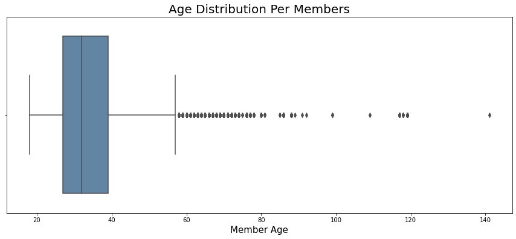

```python
# plotting of Age Distribution Per Members

plt.figure(figsize=(15,6))
sb.boxplot(x = df_cleaned.member_age, color='#5885AF')
plt.xlabel('Member Age', fontsize=15)
plt.title("Age Distribution Per Members", fontsize=20);
```

```python
# Cleaning age outliers

df_cleaned=df_cleaned[df_cleaned.member_age <= 52]
```

```python
# Test

df_cleaned.info()
```

```
<class 'pandas.core.frame.DataFrame'>
Int64Index: 163341 entries, 0 to 183411
Data columns (total 14 columns):
 #   Column                   Non-Null Count   Dtype
---  ------                   --------------   -----
 0   duration_sec             163341 non-null  int64
 1   start_time               163341 non-null  datetime64[ns]
 2   end_time                 163341 non-null  datetime64[ns]
 3   start_station_name       163341 non-null  object
 4   end_station_name         163341 non-null  object
 5   bike_id                  163341 non-null  object
 6   user_type                163341 non-null  category
 7   member_birth_year        163341 non-null  float64
 8   member_gender            163341 non-null  category
 9   bike_share_for_all_trip  163341 non-null  category
 10  start_date               163341 non-null  object
 11  start_day                163341 non-null  object
 12  start_hour               163341 non-null  object
 13  member_age               163341 non-null  float64
dtypes: category(3), datetime64[ns](2), float64(2), int64(1), object(6)
memory usage: 15.4+ MB
```

```python
# Storing the cleaned DataFrame in a CSV file

df_cleaned.to_csv('fordgobike-cleaned.csv', index = False, encoding = 'utf-8')
```

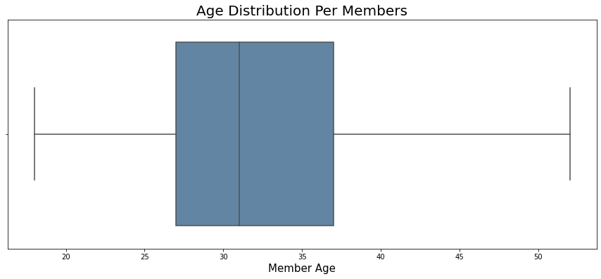

```python
plt.figure(figsize=(15,6))
sb.boxplot(x = df_cleaned.member_age, color='#5885AF')
plt.xlabel('Member Age', fontsize=15)
plt.title("Age Distribution Per Members", fontsize=20);
```

> **The figure is for testing that the outliers are successfully removed.**

### 2. Count And Percentage Of Each User Type

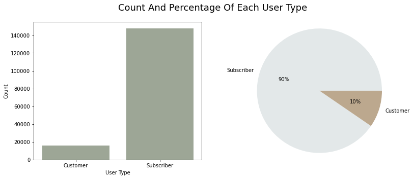

```python
# Plotting Count And Percentage Of Each User Type

plt.figure(figsize = [13, 5])

plt.subplot(1, 2, 1)
sb.countplot(x = df_cleaned.user_type, color = '#9DA993')
plt.xlabel('User Type')
plt.ylabel('Count')

plt.subplot(1, 2, 2)
plt.pie(df_cleaned.user_type.value_counts(),
        labels = df_cleaned.user_type.value_counts().keys(),
        colors = ['#E3E8E9', '#BCA88E'],
        autopct='%1.0f%%')

plt.axis('equal')

plt.suptitle('Count And Percentage Of Each User Type', fontsize=18);
```

> **The figure shows that The users majority are Subscribers with 90% while Customers are only 10%.**

### 3. Count And Percentage Of Each Member Gender

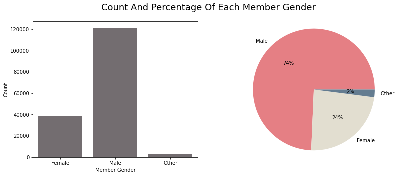

```python
# Plotting Count And Percentage Of Each Member Gender

plt.figure(figsize = [13, 5])

plt.subplot(1, 2, 1)
sb.countplot(x = df_cleaned.member_gender, color = '#746C70')
plt.xlabel('Member Gender')
plt.ylabel('Count')

plt.subplot(1, 2, 2)
plt.pie(df_cleaned.member_gender.value_counts(),
        labels = df_cleaned.member_gender.value_counts().keys(),
        colors = ['#E57F84', '#E2DED0', '#647C90'],
        autopct='%1.0f%%')

plt.axis('equal')

plt.suptitle('Count And Percentage Of Each Member Gender', fontsize=18);
```

> **The figure shows that The Users majority are Males with 74% while Females are only 24% and Others are 2%.**

### 3. Trip Count Per Week Days

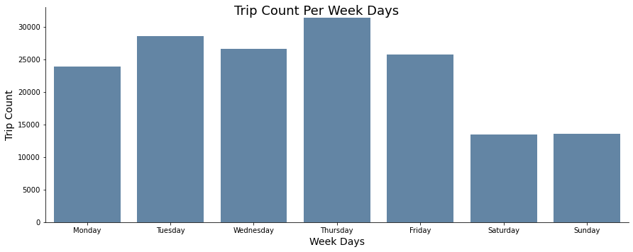

```python
# Plotting Trip Count Per Week Days

df_cleaned['start_day'] = pd.Categorical(df_cleaned['start_day'], categories=
    ['Monday','Tuesday','Wednesday','Thursday','Friday','Saturday', 'Sunday'],
    ordered=True)

sb.catplot(x = 'start_day' , data = df_cleaned, kind = 'count', color = '#5885AF', height=5, aspect=2.5)
plt.xlabel('Week Days', size=14)
plt.ylabel('Trip Count', size=14)
plt.tight_layout()
plt.suptitle('Trip Count Per Week Days', fontsize=18);
```

> **The figure shows that Rental at the minimum in weekends and reach higher values during working days and the peak is in Thursday.**

### 4. Trip Count vs. Hour Of The Day

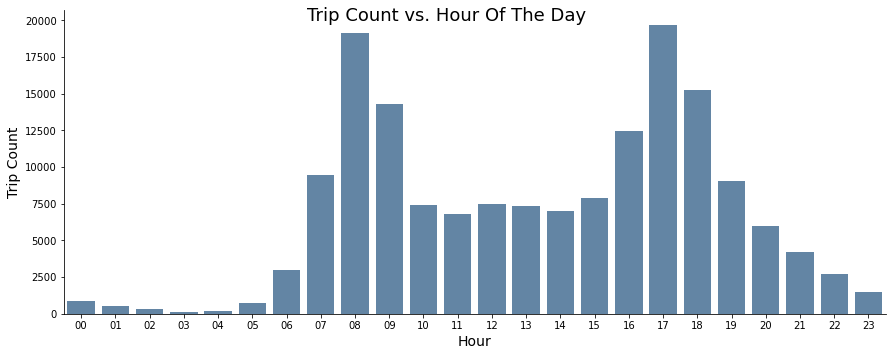

```python
# Trip Count vs. Hour Of The Day

df_sorted = df_cleaned.sort_values(by = 'start_hour', ascending = True)
sb.catplot(x = 'start_hour', data = df_sorted, kind = 'count', color = '#5885AF', height=5, aspect=2.5)
plt.xlabel('Hour', size=14)
plt.ylabel('Trip Count', size=14)
plt.tight_layout()
plt.suptitle('Trip Count vs. Hour Of The Day', fontsize=18);
```

> **The figure showing that the sevice demand peaked during 8 am and 5 pm perhapes because the majority of people going and leaving work at those times.**

### 5. Age Count

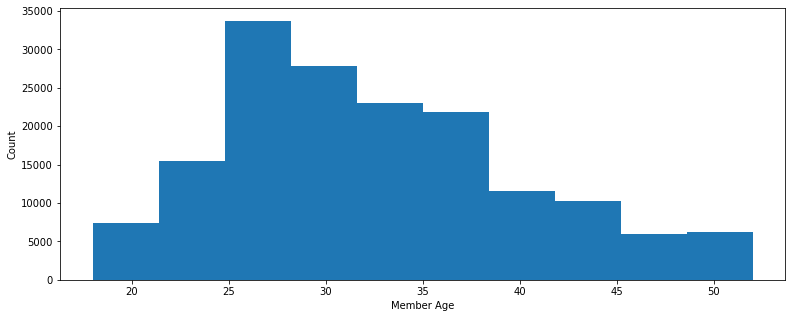

```python
# Age Count

plt.figure(figsize = [13, 5])
plt.hist(x = 'member_age', data = df_cleaned)
plt.xlabel('Member Age');
plt.ylabel('Count');
```

### 6. High Demand Stations

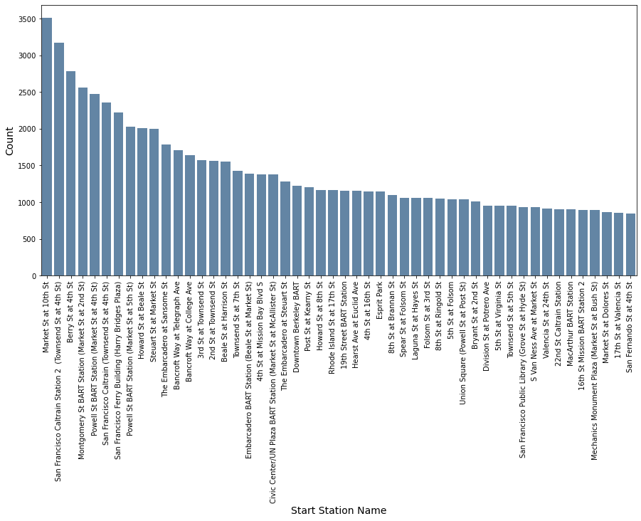

```python
# Plot of High Demand Stations

plt.figure(figsize = [15, 7])
sb.countplot(x = 'start_station_name', data = df_cleaned, color = '#5885AF',
             order = df_cleaned.start_station_name.value_counts(ascending=False)[0:50].index)
plt.xlabel('Start Station Name', fontsize=14)
plt.ylabel('Count', fontsize=14);
plt.xticks(rotation = 90, size = 10);
```

> **The figure shows that the top 50 high demand stations which needed by the supplier in order to make sure those stations are always equipped with the requested bikes.**

### Discuss the distribution(s) of your variable(s) of interest. Were there any unusual points? Did you need to perform any transformations?

> **Regarding Users, The service attracts more male users than female. Most members were Subscribers compared to Daily Customers. The majority of the members did not use bike share for all of their trips, and most were around 25 to 38 years old.**

> **The number of trips peaked around 8 am and 5 pm during a day, there were more trips on work days (Mon-Fri) compared to weekends.**

> **I cleand all variables that need to clean like change the date to datetime object,removed nan values, caclulated member age and removed the outliers.**

### Of the features you investigated, were there any unusual distributions? Did you perform any operations on the data to tidy, adjust, or change the form of the data? If so, why did you do this?

> **Yes, I've performed some operations on the data especially member age as the distribution shows that there were outliers should be cleaned, I've also changed a little bit in the structure of the data (data types and some drived coloumns) for ease of visualization and investigation.**

## Bivariate Exploration

> In this section, I will investigate the relationships between pairs of variables in my data.

### 1. The Daily Usage Per Memebers Gender

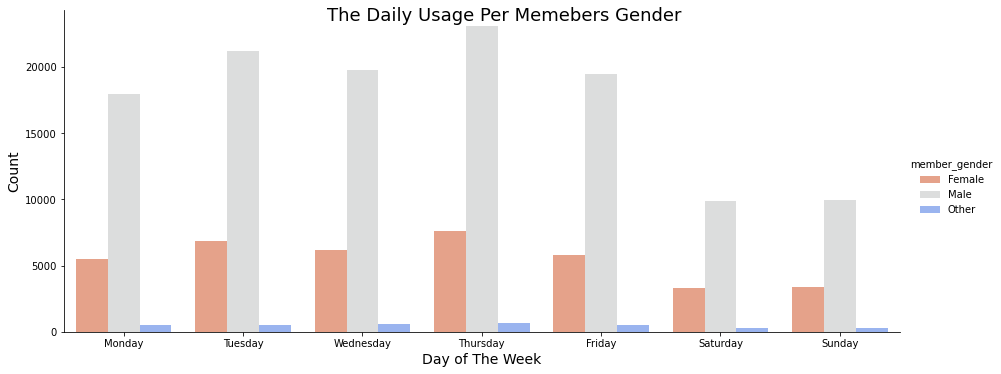

```python
# Plotting The Daily Usage Per Memebers Gender

plt.figure(figsize = [15, 7])
sb.catplot(data = df_cleaned, x = 'start_day', hue = 'member_gender', kind = 'count', aspect = 2.5, palette = 'coolwarm_r')
plt.xlabel('Day of The Week', fontsize=14)
plt.ylabel('Count', fontsize=14)
plt.suptitle('The Daily Usage Per Memebers Gender', fontsize=18);
```

> **The figure shows that the male users are the dominant users along all days of the week with no exceptions even in the weekends.**

### 2. The Daily Usage Per User Type

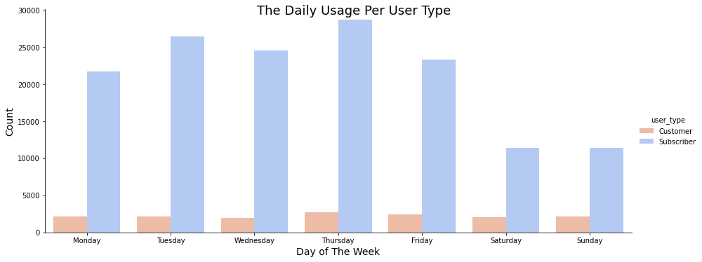

```python
# Plotting The Daily Usage Per User Type

plt.figure(figsize = [15, 7])
sb.catplot(data = df_cleaned, x = 'start_day', hue = 'user_type', kind = 'count', aspect = 2.5, palette = 'coolwarm_r')
plt.xlabel('Day of The Week', fontsize=14)
plt.ylabel('Count', fontsize=14)
plt.suptitle('The Daily Usage Per User Type', fontsize=18);
```

> **The figure shows that the Subscribers are the dominant user type along all days of the week with no exceptions even in the weekends.**

### 3. The Hourly Usage During The Day Per Memebers Gender

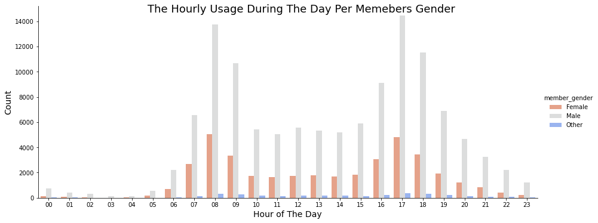

```python
# plotting The Hourly Usage During The Day Per Memebers Gender

plt.figure(figsize = [15, 7])
sb.catplot(data = df_sorted, x = 'start_hour', hue = 'member_gender', kind = 'count', aspect = 2.5, palette = 'coolwarm_r')
plt.xlabel('Hour of The Day', fontsize=14)
plt.ylabel('Count', fontsize=14)
plt.suptitle('The Hourly Usage During The Day Per Memebers Gender', fontsize=18);
```

> **The figure shows that the male users are the dominant users along all Hours of the day with no exceptions.**

### 4. The Hourly Usage During The Day Per User Type

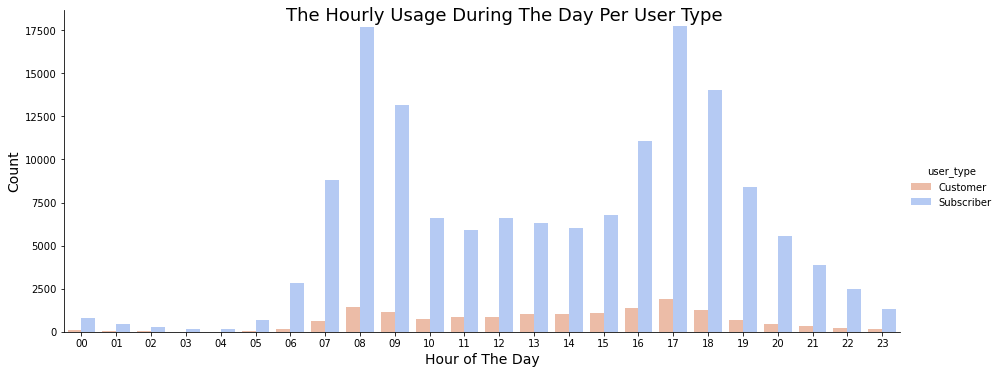

```python
# plotting The Hourly Usage During The Day Per User Type

plt.figure(figsize = [15, 7])
sb.catplot(data = df_sorted, x = 'start_hour', hue = 'user_type', kind = 'count', aspect = 2.5, palette = 'coolwarm_r')
plt.xlabel('Hour of The Day', fontsize=14)
plt.ylabel('Count', fontsize=14)
plt.suptitle('The Hourly Usage During The Day Per User Type', fontsize=18);
```

> **The figure shows that Subscribers are the dominant user type along all Hours of the day with no exceptions.**

### 5. Trip Duration Distribution Per User Type

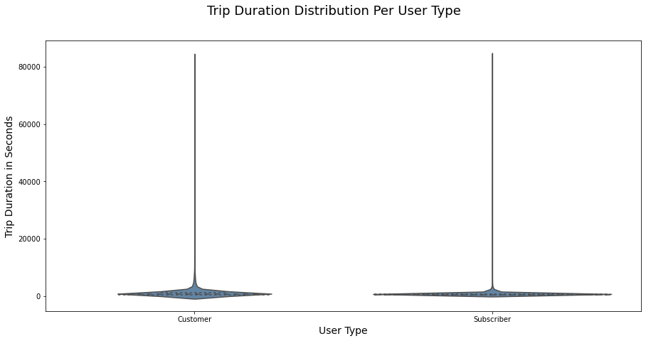

```python
# plotting Trip Duration Distribution Per User Type

plt.figure(figsize = [15, 7])
sb.violinplot(data = df_cleaned, x = 'user_type', y = 'duration_sec', color = '#5885AF', inner = 'quartile')
plt.xlabel('User Type', fontsize=14)
plt.ylabel('Trip Duration in Seconds', fontsize=14)
plt.suptitle('Trip Duration Distribution Per User Type', fontsize=18);
```

> **The trip duration distribution is narrower for subscribers than customers. Maybe subscribers have a more specific usage.**

### 6. Users Types Per Gender

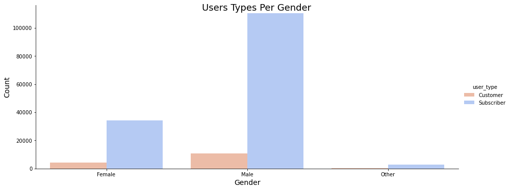

```python
# Plotting Users Types Per Gender

plt.figure(figsize = [15, 7])
sb.catplot(data = df_cleaned, x = 'member_gender', hue = 'user_type', kind = 'count', aspect = 2.5, palette = 'coolwarm_r')
plt.xlabel('Gender', fontsize=14)
plt.ylabel('Count', fontsize=14)
plt.suptitle('Users Types Per Gender', fontsize=18);
```

> **The figure shows that the Subscribers are the dominant user type among all Genders.**

### 7. Memebers Age Distribution During Days of The Week

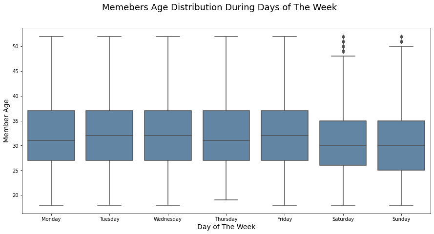

```python
# plotting Memebers Age Distribution During Days of The Week

plt.figure(figsize = [15, 7])
sb.boxplot(data = df_cleaned, x = 'start_day', y = 'member_age', color = '#5885AF')
plt.xlabel('Day of The Week', fontsize=14)
plt.ylabel('Member Age', fontsize=14)
plt.suptitle('Memebers Age Distribution During Days of The Week', fontsize=18);
```

> **The figure shows that the Users from working days are a bit older than The users from weekends.**

## Multivariate Exploration

> I will create plots of three or more variables to investigate my data even further.

### 1. The Average Trip Duration Per Days Of The Week Vs. User Type

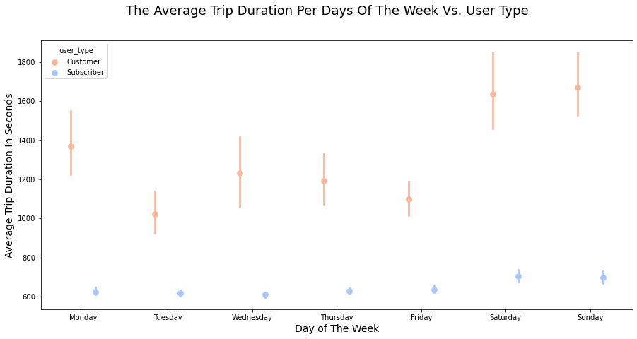

```python
# Plotting The Average Trip Duration Per Days Of The Week Vs. User Type

plt.figure(figsize = [15, 7])
sb.pointplot(data = df_cleaned, x = 'start_day', y = 'duration_sec', hue ='user_type',
             dodge = 0.3, linestyles = '', palette = 'coolwarm_r')
plt.xlabel('Day of The Week', fontsize=14)
plt.ylabel('Average Trip Duration In Seconds', fontsize=14)
plt.suptitle('The Average Trip Duration Per Days Of The Week Vs. User Type', fontsize=18);
```

> **The figure shows that subscribers trips are much quicker compared to customers on each day of the week. Both user types have an obvious increase of trip duration on Saturdays and Sundays over weekends, especially for casual riders. Subscribers usage seems to be more efficient than customers overall and maintained a very consistent average duration Monday through Friday.**

### 2. The Average Trip Duration Per Days Of The Week Vs. Gender

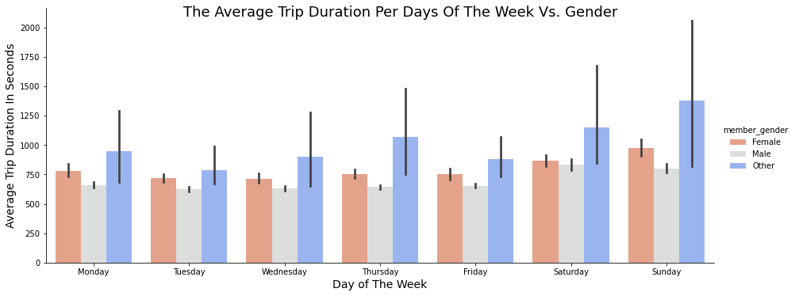

```python
# Plotting The Average Trip Duration Per Days Of The Week Vs. Gender

plt.figure(figsize = [15, 7])
sb.catplot(data = df_cleaned, x = 'start_day', y = 'duration_sec', hue ='member_gender',
             kind = 'bar', aspect = 2.5, palette = 'coolwarm_r')
plt.xlabel('Day of The Week', fontsize=14)
plt.ylabel('Average Trip Duration In Seconds', fontsize=14)
plt.suptitle('The Average Trip Duration Per Days Of The Week Vs. Gender', fontsize=18);
```

### Were there any interesting or surprising interactions between features?

> **The Interesting finding was that females and others in gender are more enjoying the service than males and take more time in thier trips.**